D208 - NBM NBM2 TASK 1 MULTIPLE REGRESSION FOR PREDICTIVE MODELING By: Vera Lake Student Id: 000929765

# Part I: Research Question

## A. Describe the purpose of this data analysis by doing the following:

1. Summarize one research question that is relevant to a real-world organizational situation captured in the data set you have selected and that you will answer using multiple regression.
   - Which customer features/variables are most significant to reduce churn?
2. Define the objectives or goals of the data analysis. Ensure that your objectives or goals are reasonable within the scope of the data dictionary and are represented in the available data.
   - The objective of the data analysis is to uncover which features (variables) impact churn negatively and which impact churn positively. A negative coefficient returned by the multiple linear regression model indicates that the feature is predicted to reduce churn and a positive coefficient will indicate that the feature increases the probability a customer will churn. We want to take the returned information and make recommendations to the stakeholders on how to reduce the churn rate for their customers.

# Part II: Method Justification

## B. Describe multiple regression methods by doing the following:

1. Summarize the assumptions of a multiple regression model.\

   There are four assumptions of multiple regression methods:\ a) Variables are normally distributed. This means the variables are not highly skewed or kurtotic, or include substantial outliers.\ b) There is a linear relationship between the independent variable (IV) and the dependent variable (DV). If the relationship is not linear the results of the regression analysis will under-estimate the relationship. \ c) Variables are measured without error reliably. \ d) Homoscedasticity for all IVs. This means that the variance of errors is the same across all levels of the IVs. (Osborn, J. W., & Waters, E., 2002)
2. Describe the benefits of using the tool(s) you have chosen (i.e., Python, R, or both) in support of various phases of the analysis.\

   The benefits of using Python to support the various phases of the analysis are: I am more proficient with Python than R and Python has a wide support and libraries for multiple regression models.
3. Explain why multiple regression is an appropriate technique to analyze the research question summarized in Part I.\

Multiple regression is a statistical technique that can be used to analyze the relationship between a single dependent variable and several independent variables. The objective of multiple regression analysis is to use the independent variables whose values are known to predict the value of the single dependent value. (https://www.sciencedirect.com/topics/social-sciences/multiple-regression)

# Part III: Data Preparation

## C. Summarize the data preparation process for multiple regression analysis by doing the following:

1. Describe your data preparation goals and the data manipulations that will be used to achieve the goals.\

The data preparation goals and data manipulations that will be used to achieve the goals are will be accomplished in the following phases:\ (Larose, C. D., & Larose, D. T. (2019))

**Data Preparation Goals and Manipulations**\ My plan is to prepare the data based on the on the four assumptions of multiple regression. In a forecasting situation, the inclusion of variables that do not significantly contribute to the regression merely inflate the error of the resulting prediction.

• The cost of monitoring many variables may be very high – so it is advisable to exclude variables that are not contributing significantly.

• There is no point including terms that contribute less than the error variance, unless there is strong prior evidence that a particular variable should be included.

• For successful forecasting, an equation that is stable over a wide range of conditions is necessary. The smaller the number of variables in the equation, the more stable and reliable the equation.

a) Variables are normally distributed. This means the variables are not highly skewed or kurtotic, or include substantial outliers.

- univariate analysis and outlier detection and removal methods will be used to meet this assumption b) There is a linear relationship between the independent variable (IV) and the dependent variable (DV). If the relationship is not linear the results of the regression analysis will under-estimate the relationship.
- define independent and dependent variable
- bivariate analysis will be used to determine whether there is a linear relationship between the target variable, Churn, and the potential predictor variables. c) Variables are measured without error reliably. d) Homoscedasticity for all IVs. This means that the variance of errors is the same across all levels of the IVs. (Osborn, J. W., & Waters, E., 2002) A. Add an index field - the index field was added as a column to the dataframe.\ B. Change misleading field values - all misleading field values were either updated or removed from the dataframe.\ C. Drop unnecessary columns - unnecessary columns included identifier field and columns that did not influence churn.\ D. Reexpress categorical data as numeric data - all categorical data was reexpressed in new columns as numeric data.\ E. Standardize the numeric fields - all numeric fields were standardized.\ F. Identify Outliers - outliers will be identified and left present in the data because it is unknown how the stakeholder would want to handle the outliers.
1. Discuss the summary statistics, including the target variable and all predictor variables that you will need to gather from the data set to answer the research question.

The summary statistics are as follows: An overview of the variables:

**Target Variable** Churn is a binary categorical variable with the values "Yes" and "No". The target variable is the variable whose values are to be modeled and predicted by the predictor variables.

**Predictor Variables** The variables in this data set describe the customer information for a subscription based service including demographics, spending information, and whether the customer has churned or not. See OUt[3] for a list of data types: int64, float64, and objects. See the first 5 rows of Out[4] and Out[5] for a more detailed view of the variables.

**Categorical Variables** A categorical predictor variable is sometimes called a factor.

**Continuous Variables** A continuous predictor variable is sometimes called a covariate.

- Population: Population within a mile radius of customer, based on census data
- Children: Number of children in customer’s household as reported in sign-upinformation
- Age: Age of customer as reported in sign-up information
- Income: Annual income of customer as reported at time of sign-up
- Email: Number of emails sent to the customer in the last year (marketing or correspondence)
- Yearly_equip_failure: The number of times customer’s equipment failed and had to be reset/replaced in the past year
- Tenure: Number of months the customer has stayed with the provider
- MonthlyCharge: The amount charged to the customer monthly. This value reflects an average per customer.
- Bandwidth_GB_Year: The average amount of data used, in GB, in a year by the customer
- Contacts: Number of times customer contacted technical support

**Discrete Ordinal Variables** The following variables represent responses to an eight-question survey asking customers to rate the importance of various factors/surfaces on a scale of 1 to 8 (1 = most important, 8 = least important)\

If you have a discrete variable and you want to include it in a Regression or ANOVA model, you can decide whether to treat it as a continuous predictor (covariate) or categorical predictor (factor). If the discrete variable has many levels, then it may be best to treat it as a continuous variable. Treating a predictor as a continuous variable implies that a simple linear or polynomial function can adequately describe the relationship between the response and the predictor. When you treat a predictor as a categorical variable, a distinct response value is fit to each level of the variable without regard to the order of the predictor levels. Use this information, in addition to the purpose of your analysis to decide what is best for your situation. (https://support.minitab.com/en-us/minitab-express/1/help-and-how-to/modeling-statistics/regression/supporting-topics/basics/what-are-categorical-discrete-and-continuous-variables/#:~:text=Categorical%20variables%20contain%20a%20finite,material%20type%2C%20and%20payment%20method.&text=Discrete%20variables%20are%20numeric%20variables,values%20between%20any%20two%20values.)

Need to rename these

- Item1: Timely response
- Item2: Timely fixes
- Item3: Timely replacements
- Item4: Reliability
- Item5: Options
- Item6: Respectful response
- Item7: Courteous exchange
- Item8: Evidence of active listening

**Identifiers**

- CaseOrder: A placeholder variable to preserve the original order of the raw data file
- Customer_id: Unique customer ID
- Interaction, UID: Unique IDs related to customer transactions, technical support, and sign-ups

**Drop a feature if...**

- Dependent on churn
- Does not significantly contribute to churn
- Pick 4 at a maximum to increase accuracy of the model
- terms that contribute less than the error variance, unless there is strong prior evidence that a particular variable should be included
- Variables are not normally distributed. This means the variables are highly skewed or kurtotic, or include substantial outliers.
- There is not a linear relationship between the independent variable (IV) and the dependent variable (DV). If the relationship is not linear the results of the regression analysis will under-estimate the relationship.
- Multicollinearity is present

```python
# import
%matplotlib inline

import numpy as np
import pandas as pd
import matplotlib.pyplot as plt
import seaborn as sns
from sklearn.model_selection import train_test_split
from sklearn import linear_model
import statsmodels.api as sm

# Ignore Warning Code
import warnings
warnings.filterwarnings('ignore')
```

```python
# convert clv to dataframe
df = pd.read_csv("churn_data/churn_raw_data.csv")
```

```python
# display the first 5 columns and their data to get an idea of what
# kind of data we have
pd.set_option('display.max_columns', None)
pd.set_option('display.max_rows', None)
df.dtypes
```

```
Unnamed: 0                int64
CaseOrder                 int64
Customer_id              object
Interaction              object
City                     object
State                    object
County                   object
Zip                       int64
Lat                     float64
Lng                     float64
Population                int64
Area                     object
Timezone                 object
Job                      object
Children                float64
Age                     float64
Education                object
Employment               object
Income                  float64
Marital                  object
Gender                   object
Churn                    object
Outage_sec_perweek      float64
Email                     int64
Contacts                  int64
Yearly_equip_failure      int64
Techie                   object
Contract                 object
Port_modem               object
Tablet                   object
InternetService          object
Phone                    object
Multiple                 object
OnlineSecurity           object
OnlineBackup             object
DeviceProtection         object
TechSupport              object
StreamingTV              object
StreamingMovies          object
PaperlessBilling         object
PaymentMethod            object
Tenure                  float64
MonthlyCharge           float64
Bandwidth_GB_Year       float64
item1                     int64
item2                     int64
item3                     int64
item4                     int64
item5                     int64
item6                     int64
item7                     int64
item8                     int64
dtype: object
```

```python
df.head(5)
```

|  | Unnamed: 0 | CaseOrder | Customer_id | Interaction | City | State | County | Zip | Lat | Lng | Population | Area | Timezone | Job | Children | Age | Education | Employment | Income | Marital | Gender | Churn | Outage_sec_perweek | Email | Contacts | Yearly_equip_failure | Techie | Contract | Port_modem | … |
| --- | --- | --- | --- | --- | --- | --- | --- | --- | --- | --- | --- | --- | --- | --- | --- | --- | --- | --- | --- | --- | --- | --- | --- | --- | --- | --- | --- | --- | --- | --- |
| 0 | 1 | 1 | K409198 | aa90260b-4141-4a24-8e36-b04ce1f4f77b | Point Baker | AK | Prince of Wales-Hyder | 99927 | 56.25100 | -133.37571 | 38 | Urban | America/Sitka | Environmental health practitioner | NaN | 68.0 | Master's Degree | Part Time | 28561.99 | Widowed | Male | No | 6.972566 | 10 | 0 | 1 | No | One year | Yes | … |
| 1 | 2 | 2 | S120509 | fb76459f-c047-4a9d-8af9-e0f7d4ac2524 | West Branch | MI | Ogemaw | 48661 | 44.32893 | -84.24080 | 10446 | Urban | America/Detroit | Programmer, multimedia | 1.0 | 27.0 | Regular High School Diploma | Retired | 21704.77 | Married | Female | Yes | 12.014541 | 12 | 0 | 1 | Yes | Month-to-month | No | … |
| 2 | 3 | 3 | K191035 | 344d114c-3736-4be5-98f7-c72c281e2d35 | Yamhill | OR | Yamhill | 97148 | 45.35589 | -123.24657 | 3735 | Urban | America/Los_Angeles | Chief Financial Officer | 4.0 | 50.0 | Regular High School Diploma | Student | NaN | Widowed | Female | No | 10.245616 | 9 | 0 | 1 | Yes | Two Year | Yes | … |
| 3 | 4 | 4 | D90850 | abfa2b40-2d43-4994-b15a-989b8c79e311 | Del Mar | CA | San Diego | 92014 | 32.96687 | -117.24798 | 13863 | Suburban | America/Los_Angeles | Solicitor | 1.0 | 48.0 | Doctorate Degree | Retired | 18925.23 | Married | Male | No | 15.206193 | 15 | 2 | 0 | Yes | Two Year | No | … |
| 4 | 5 | 5 | K662701 | 68a861fd-0d20-4e51-a587-8a90407ee574 | Needville | TX | Fort Bend | 77461 | 29.38012 | -95.80673 | 11352 | Suburban | America/Chicago | Medical illustrator | 0.0 | 83.0 | Master's Degree | Student | 40074.19 | Separated | Male | Yes | 8.960316 | 16 | 2 | 1 | No | Month-to-month | Yes | … |

```python
# describe the data
df.describe()
```

|  | Unnamed: 0 | CaseOrder | Zip | Lat | Lng | Population | Children | Age | Income | Outage_sec_perweek | Email | Contacts | Yearly_equip_failure | Tenure | MonthlyCharge | Bandwidth_GB_Year | item1 | item2 | item3 | item4 | item5 | item6 | item7 | item8 |
| --- | --- | --- | --- | --- | --- | --- | --- | --- | --- | --- | --- | --- | --- | --- | --- | --- | --- | --- | --- | --- | --- | --- | --- | --- |
| count | 10000.00000 | 10000.00000 | 10000.000000 | 10000.000000 | 10000.000000 | 10000.000000 | 7505.000000 | 7525.000000 | 7510.000000 | 10000.000000 | 10000.000000 | 10000.000000 | 10000.000000 | 9069.000000 | 10000.000000 | 8979.000000 | 10000.000000 | 10000.000000 | 10000.000000 | 10000.000000 | 10000.000000 | 10000.000000 | 10000.000000 | 10000.000000 |
| mean | 5000.50000 | 5000.50000 | 49153.319600 | 38.757567 | -90.782536 | 9756.562400 | 2.095936 | 53.275748 | 39936.762226 | 11.452955 | 12.016000 | 0.994200 | 0.398000 | 34.498858 | 174.076305 | 3398.842752 | 3.490800 | 3.505100 | 3.487000 | 3.497500 | 3.492900 | 3.497300 | 3.509500 | 3.495600 |
| std | 2886.89568 | 2886.89568 | 27532.196108 | 5.437389 | 15.156142 | 14432.698671 | 2.154758 | 20.753928 | 28358.469482 | 7.025921 | 3.025898 | 0.988466 | 0.635953 | 26.438904 | 43.335473 | 2187.396807 | 1.037797 | 1.034641 | 1.027977 | 1.025816 | 1.024819 | 1.033586 | 1.028502 | 1.028633 |
| min | 1.00000 | 1.00000 | 601.000000 | 17.966120 | -171.688150 | 0.000000 | 0.000000 | 18.000000 | 740.660000 | -1.348571 | 1.000000 | 0.000000 | 0.000000 | 1.000259 | 77.505230 | 155.506715 | 1.000000 | 1.000000 | 1.000000 | 1.000000 | 1.000000 | 1.000000 | 1.000000 | 1.000000 |
| 25% | 2500.75000 | 2500.75000 | 26292.500000 | 35.341828 | -97.082813 | 738.000000 | 0.000000 | 35.000000 | 19285.522500 | 8.054362 | 10.000000 | 0.000000 | 0.000000 | 7.890442 | 141.071078 | 1234.110529 | 3.000000 | 3.000000 | 3.000000 | 3.000000 | 3.000000 | 3.000000 | 3.000000 | 3.000000 |
| 50% | 5000.50000 | 5000.50000 | 48869.500000 | 39.395800 | -87.918800 | 2910.500000 | 1.000000 | 53.000000 | 33186.785000 | 10.202896 | 12.000000 | 1.000000 | 0.000000 | 36.196030 | 169.915400 | 3382.424000 | 3.000000 | 4.000000 | 3.000000 | 3.000000 | 3.000000 | 3.000000 | 4.000000 | 3.000000 |
| 75% | 7500.25000 | 7500.25000 | 71866.500000 | 42.106908 | -80.088745 | 13168.000000 | 3.000000 | 71.000000 | 53472.395000 | 12.487644 | 14.000000 | 2.000000 | 1.000000 | 61.426670 | 203.777441 | 5587.096500 | 4.000000 | 4.000000 | 4.000000 | 4.000000 | 4.000000 | 4.000000 | 4.000000 | 4.000000 |
| max | 10000.00000 | 10000.00000 | 99929.000000 | 70.640660 | -65.667850 | 111850.000000 | 10.000000 | 89.000000 | 258900.700000 | 47.049280 | 23.000000 | 7.000000 | 6.000000 | 71.999280 | 315.878600 | 7158.982000 | 7.000000 | 7.000000 | 8.000000 | 7.000000 | 7.000000 | 8.000000 | 7.000000 | 8.000000 |

```python
df['index'] = pd.Series(range(0,10000))
df.head(5)
```

|  | Unnamed: 0 | CaseOrder | Customer_id | Interaction | City | State | County | Zip | Lat | Lng | Population | Area | Timezone | Job | Children | Age | Education | Employment | Income | Marital | Gender | Churn | Outage_sec_perweek | Email | Contacts | Yearly_equip_failure | Techie | Contract | Port_modem | … |
| --- | --- | --- | --- | --- | --- | --- | --- | --- | --- | --- | --- | --- | --- | --- | --- | --- | --- | --- | --- | --- | --- | --- | --- | --- | --- | --- | --- | --- | --- | --- |
| 0 | 1 | 1 | K409198 | aa90260b-4141-4a24-8e36-b04ce1f4f77b | Point Baker | AK | Prince of Wales-Hyder | 99927 | 56.25100 | -133.37571 | 38 | Urban | America/Sitka | Environmental health practitioner | NaN | 68.0 | Master's Degree | Part Time | 28561.99 | Widowed | Male | No | 6.972566 | 10 | 0 | 1 | No | One year | Yes | … |
| 1 | 2 | 2 | S120509 | fb76459f-c047-4a9d-8af9-e0f7d4ac2524 | West Branch | MI | Ogemaw | 48661 | 44.32893 | -84.24080 | 10446 | Urban | America/Detroit | Programmer, multimedia | 1.0 | 27.0 | Regular High School Diploma | Retired | 21704.77 | Married | Female | Yes | 12.014541 | 12 | 0 | 1 | Yes | Month-to-month | No | … |
| 2 | 3 | 3 | K191035 | 344d114c-3736-4be5-98f7-c72c281e2d35 | Yamhill | OR | Yamhill | 97148 | 45.35589 | -123.24657 | 3735 | Urban | America/Los_Angeles | Chief Financial Officer | 4.0 | 50.0 | Regular High School Diploma | Student | NaN | Widowed | Female | No | 10.245616 | 9 | 0 | 1 | Yes | Two Year | Yes | … |
| 3 | 4 | 4 | D90850 | abfa2b40-2d43-4994-b15a-989b8c79e311 | Del Mar | CA | San Diego | 92014 | 32.96687 | -117.24798 | 13863 | Suburban | America/Los_Angeles | Solicitor | 1.0 | 48.0 | Doctorate Degree | Retired | 18925.23 | Married | Male | No | 15.206193 | 15 | 2 | 0 | Yes | Two Year | No | … |
| 4 | 5 | 5 | K662701 | 68a861fd-0d20-4e51-a587-8a90407ee574 | Needville | TX | Fort Bend | 77461 | 29.38012 | -95.80673 | 11352 | Suburban | America/Chicago | Medical illustrator | 0.0 | 83.0 | Master's Degree | Student | 40074.19 | Separated | Male | Yes | 8.960316 | 16 | 2 | 1 | No | Month-to-month | Yes | … |

B. Change misleading field values of the following fields for clarity and consistency

Employment: Employment status of customer as reported in sign-up information. Rename to Employment_Status\ Marital: Marital status of customer as reported in sign-up information. Rename to Marital_Status\ Outage_sec_perweek: Average number of seconds per week of system outages in the customer’s neighborhood. Rename to Outage_Seconds_Per_Week\ Contacts: Number of times customer contacted technical support. Rename to Technical_Support_Contacted_Count\ Techie: Whether the customer considers themselves technically inclined (based on customer questionnaire when they signed up for services) (yes, no). Rename to Is_Techie\ Contract: The contract term of the customer (month-to-month, one year, two year). Rename to Contract_Term\ Port_modem: Whether the customer has a portable modem (yes, no). Rename to Has_Port_Modem\ Tablet: Whether the customer owns a tablet such as iPad, Surface, etc. (yes, no). Rename to Has_Tablet\ InternetService: Customer’s internet service provider (DSL, fiber optic, None). Rename to Internet_Service_Type\ Phone: Whether the customer has a phone service (yes, no). Rename to Has_Phone_Service\ Multiple: Whether the customer has multiple lines (yes, no). Rename to Has_Multiple_Lines\ OnlineSecurity: Whether the customer has an online security add-on (yes, no). Rename to Has_Online_Security\ OnlineBackup: Whether the customer has an online backup add-on (yes, no) Rename to Has_Online_Backup\ DeviceProtection: Whether the customer has device protection add-on (yes, no). Rename to Has_Device_Protection\ TechSupport: Whether the customer has a technical support add-on (yes, no). Rename to Has_Tech_Support\ StreamingTV: Whether the customer has streaming TV (yes, no). Rename to Has_Streaming_TV\ StreamingMovies: Whether the customer has streaming movies (yes, no). Rename to Has_Streaming_Movies\ PaperlessBilling: Whether the customer has paperless billing (yes, no) Rename to Has_Paperless_Billing\ PaymentMethod: The customer’s payment method (electronic check, mailed check, bank (automatic bank transfer), credit card (automatic)). Rename to Payment_Method_Type\ Item1: Timely response. Rename to Timely_Response_Survey_Item\ Item2: Timely fixes. Rename to Timely_Fixes_Survey_Item\ Item3: Timely replacements. Rename to Timely_Replacements_Survey_Item\ Item4: Reliability. Rename to Reliability_Survey_Item\ Item5: Options. Rename to Options_Survey_Item\ Item6: Respectful response. Rename to Respectful_Response_Survey_Item\ Item7: Courteous exchange. Rename to Courteous_Exchange_Survey_Item\ Item8: Evidence of active listening. Rename to Evidence_Of_Active_Listening_Survey_Item\ Population: Population within a mile radius of customer, based on census data. Rename to Population_Within_A_Mile\ Children: Number of children in customer’s household as reported in sign-up information. Rename to Children_Count\ Age: Age of customer as reported in sign-up information.\ Income: Annual income of customer as reported at time of sign-up\ Email: Number of emails sent to the customer in the last year (marketing or correspondence). Rename to Email_Sent_To_Customer_Count\ Yearly_equip_failure: The number of times customer’s equipment failed and had to be reset/replaced in the past year. Rename to Yearly_Equip_Failure_Count\ MonthlyCharge: The amount charged to the customer monthly. This value reflects an average per customer. Rename to Avg_Monthly_Charge\ Bandwidth_GB_Year: The average amount of data used, in GB, in a year by the customer. Rename to Avg_Bandwidth_GB_Usage_Per_Year\ CaseOrder: A placeholder variable to preserve the original order of the raw data file. Rename to Case_Order_Placeholder\ Customer_id: Unique customer ID. Rename to Customer_ID\ Interaction: Unique IDs related to customer transactions, technical support, and sign-ups. Rename to Interaction_UID\

```python
df = df.rename(columns={
    "Employment": "Employment_Status",
    "Marital":"Marital_Status",
    "Outage_sec_perweek": "Outage_Seconds_Per_Week",
    "Contacts": "Technical_Support_Contacted_Count",
    "Techie": "Is_Techie",
    "Contract": "Contract_Term",
    "Port_modem": "Has_Port_Modem",
    "Tablet": "Has_Tablet",
    "InternetService": "Internet_Service_Type",
    "Phone":"Has_Phone_Service",
    "Multiple":"Has_Multiple_Lines",
    "OnlineSecurity": "Has_Online_Security",
    "OnlineBackup": "Has_Online_Backup",
    "DeviceProtection": "Has_Device_Protection",
    "TechSupport":"Has_Tech_Support",
    "StreamingTV": "Has_Streaming_TV",
    "StreamingMovies": "Has_Streaming_Movies",
    "PaperlessBilling": "Has_Paperless_Billing",
    "PaymentMethod": "Payment_Method_Type",
    "item1": "Timely_Response_Survey_Item",
    "item2": "Timely_Fixes_Survey_Item",
    "item3": "Timely_Replacements_Survey_Item",
    "item4": "Reliability_Survey_Item",
    "item5": "Options_Survey_Item",
    "item6": "Respectful_Response_Survey_Item",
    "item7": "Courteous_Exchange_Survey_Item",
    "item8": "Evidence_Of_Active_Listening_Survey_Item",
    "Population": "Population_Within_A_Mile",
    "Children": "Children_Count",
    "Email": "Email_Sent_To_Customer_Count",
    "Yearly_equip_failure": "Yearly_Equip_Failure_Count",
    "MonthlyCharge": "Avg_Monthly_Charge",
    "Bandwidth_GB_Year": "Avg_Bandwidth_GB_Usage_Per_Year",
    "CaseOrder": "Case_Order_Placeholder",
    "Customer_id": "Customer_ID",
    "Interaction": "Interaction_UID"
})
df.head(1)
```

|  | Unnamed: 0 | Case_Order_Placeholder | Customer_ID | Interaction_UID | City | State | County | Zip | Lat | Lng | Population_Within_A_Mile | Area | Timezone | Job | Children_Count | Age | Education | Employment_Status | Income | Marital_Status | Gender | Churn | Outage_Seconds_Per_Week | Email_Sent_To_Customer_Count | Technical_Support_Contacted_Count | Yearly_Equip_Failure_Count | Is_Techie | Contract_Term | Has_Port_Modem | … |
| --- | --- | --- | --- | --- | --- | --- | --- | --- | --- | --- | --- | --- | --- | --- | --- | --- | --- | --- | --- | --- | --- | --- | --- | --- | --- | --- | --- | --- | --- | --- |
| 0 | 1 | 1 | K409198 | aa90260b-4141-4a24-8e36-b04ce1f4f77b | Point Baker | AK | Prince of Wales-Hyder | 99927 | 56.251 | -133.37571 | 38 | Urban | America/Sitka | Environmental health practitioner | NaN | 68.0 | Master's Degree | Part Time | 28561.99 | Widowed | Male | No | 6.972566 | 10 | 0 | 1 | No | One year | Yes | … |

```python
df.dtypes
```

```
Unnamed: 0                                    int64
Case_Order_Placeholder                        int64
Customer_ID                                  object
Interaction_UID                              object
City                                         object
State                                        object
County                                       object
Zip                                           int64
Lat                                         float64
Lng                                         float64
Population_Within_A_Mile                      int64
Area                                         object
Timezone                                     object
Job                                          object
Children_Count                              float64
Age                                         float64
Education                                    object
Employment_Status                            object
Income                                      float64
Marital_Status                               object
Gender                                       object
Churn                                        object
Outage_Seconds_Per_Week                     float64
Email_Sent_To_Customer_Count                  int64
Technical_Support_Contacted_Count             int64
Yearly_Equip_Failure_Count                    int64
Is_Techie                                    object
Contract_Term                                object
Has_Port_Modem                               object
Has_Tablet                                   object
Internet_Service_Type                        object
Has_Phone_Service                            object
Has_Multiple_Lines                           object
Has_Online_Security                          object
Has_Online_Backup                            object
Has_Device_Protection                        object
Has_Tech_Support                             object
Has_Streaming_TV                             object
Has_Streaming_Movies                         object
Has_Paperless_Billing                        object
Payment_Method_Type                          object
Tenure                                      float64
Avg_Monthly_Charge                          float64
Avg_Bandwidth_GB_Usage_Per_Year             float64
Timely_Response_Survey_Item                   int64
Timely_Fixes_Survey_Item                      int64
Timely_Replacements_Survey_Item               int64
Reliability_Survey_Item                       int64
Options_Survey_Item                           int64
Respectful_Response_Survey_Item               int64
Courteous_Exchange_Survey_Item                int64
Evidence_Of_Active_Listening_Survey_Item      int64
index                                         int64
dtype: object
```

3.C

During the process of creating feature groups, do not include unnecessary columns - unnecessary columns included identifier variables and variables that are deemed redundant for our purposes. **Identifiers:** Interaction_UID, Customer_ID, and Case_Order_Placeholder

**Redundant Variables** Lat, Lng, City, Zipcode, County, and Timezone can be categorized with the state.

**Identify predictor variables that do not influence churn and drop them** This will be done during bivariate analysis of the data.

```python
# Group data by type - continuous, categorical, discreet ordinal
categorical_variables = df[[
    "City",
    "State",
    "Area",
    "County",
    "Timezone",
    "Job",
    "Education",
    "Employment_Status",
    "Marital_Status",
    "Gender",
    "Is_Techie",
    "Contract_Term",
    "Has_Port_Modem",
    "Has_Tablet",
    "Internet_Service_Type",
    "Has_Phone_Service",
    "Has_Multiple_Lines",
    "Has_Online_Security",
    "Has_Online_Backup",
    "Has_Device_Protection",
    "Has_Tech_Support",
    "Has_Streaming_TV",
    "Has_Streaming_Movies",
    "Has_Paperless_Billing",
    "Payment_Method_Type"
]]

continuous_variables = df[[
    "Population_Within_A_Mile",
    "Children_Count",
    "Age",
    "Income",
    "Outage_Seconds_Per_Week",
    "Email_Sent_To_Customer_Count",
    "Technical_Support_Contacted_Count",
    "Yearly_Equip_Failure_Count",
    "Tenure",
    "Avg_Monthly_Charge",
    "Avg_Bandwidth_GB_Usage_Per_Year"]
]

discrete_ordinal_variables = df[[
    "Timely_Response_Survey_Item",
    "Timely_Fixes_Survey_Item",
    "Timely_Replacements_Survey_Item",
    "Reliability_Survey_Item",
    "Options_Survey_Item",
    "Respectful_Response_Survey_Item",
    "Courteous_Exchange_Survey_Item",
    "Evidence_Of_Active_Listening_Survey_Item"]
]

predictor_variables = pd.concat([categorical_variables, continuous_variables, discrete_ordinal_variables], axis=1)
target = df[["Churn"]]
```

```python
categorical_variables.head(1)
```

|  | City | State | Area | County | Timezone | Job | Education | Employment_Status | Marital_Status | Gender | Is_Techie | Contract_Term | Has_Port_Modem | Has_Tablet | Internet_Service_Type | Has_Phone_Service | Has_Multiple_Lines | Has_Online_Security | Has_Online_Backup | Has_Device_Protection | Has_Tech_Support | Has_Streaming_TV | Has_Streaming_Movies | Has_Paperless_Billing | Payment_Method_Type |
| --- | --- | --- | --- | --- | --- | --- | --- | --- | --- | --- | --- | --- | --- | --- | --- | --- | --- | --- | --- | --- | --- | --- | --- | --- | --- |
| 0 | Point Baker | AK | Urban | Prince of Wales-Hyder | America/Sitka | Environmental health practitioner | Master's Degree | Part Time | Widowed | Male | No | One year | Yes | Yes | Fiber Optic | Yes | No | Yes | Yes | No | No | No | Yes | Yes | Credit Card (automatic) |

```python
continuous_variables.head(1)
```

|  | Population_Within_A_Mile | Children_Count | Age | Income | Outage_Seconds_Per_Week | Email_Sent_To_Customer_Count | Technical_Support_Contacted_Count | Yearly_Equip_Failure_Count | Tenure | Avg_Monthly_Charge | Avg_Bandwidth_GB_Usage_Per_Year |
| --- | --- | --- | --- | --- | --- | --- | --- | --- | --- | --- | --- |
| 0 | 38 | NaN | 68.0 | 28561.99 | 6.972566 | 10 | 0 | 1 | 6.795513 | 171.449762 | 904.53611 |

```python
discrete_ordinal_variables.head(1)
```

|  | Timely_Response_Survey_Item | Timely_Fixes_Survey_Item | Timely_Replacements_Survey_Item | Reliability_Survey_Item | Options_Survey_Item | Respectful_Response_Survey_Item | Courteous_Exchange_Survey_Item | Evidence_Of_Active_Listening_Survey_Item |
| --- | --- | --- | --- | --- | --- | --- | --- | --- |
| 0 | 5 | 5 | 5 | 3 | 4 | 4 | 3 | 4 |

```python
predictor_variables.head(1)
```

|  | City | State | Area | County | Timezone | Job | Education | Employment_Status | Marital_Status | Gender | Is_Techie | Contract_Term | Has_Port_Modem | Has_Tablet | Internet_Service_Type | Has_Phone_Service | Has_Multiple_Lines | Has_Online_Security | Has_Online_Backup | Has_Device_Protection | Has_Tech_Support | Has_Streaming_TV | Has_Streaming_Movies | Has_Paperless_Billing | Payment_Method_Type | Population_Within_A_Mile | Children_Count | Age | Income | … |
| --- | --- | --- | --- | --- | --- | --- | --- | --- | --- | --- | --- | --- | --- | --- | --- | --- | --- | --- | --- | --- | --- | --- | --- | --- | --- | --- | --- | --- | --- | --- |
| 0 | Point Baker | AK | Urban | Prince of Wales-Hyder | America/Sitka | Environmental health practitioner | Master's Degree | Part Time | Widowed | Male | No | One year | Yes | Yes | Fiber Optic | Yes | No | Yes | Yes | No | No | No | Yes | Yes | Credit Card (automatic) | 38 | NaN | 68.0 | 28561.99 | … |

## Univariate Visualization and Analysis

### Categorical Variables

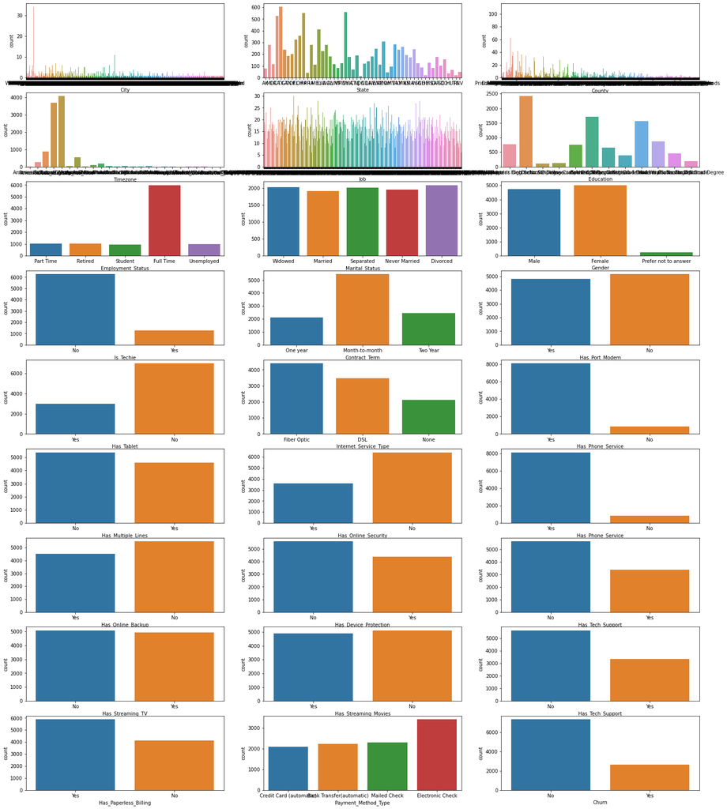

```python
# Univariate analysis
fig, ax =plt.subplots(9,3,figsize=(25,30))

sns.countplot(df['City'], ax=ax[0][0])
sns.countplot(df['State'], ax=ax[0][1])
sns.countplot(df['County'], ax=ax[0][2])

sns.countplot(df['Timezone'], ax=ax[1][0])
sns.countplot(df['Job'], ax=ax[1][1])
sns.countplot(df['Education'], ax=ax[1][2])

sns.countplot(df['Employment_Status'], ax=ax[2][0])
sns.countplot(df['Marital_Status'], ax=ax[2][1])
sns.countplot(df['Gender'], ax=ax[2][2])

sns.countplot(df['Is_Techie'], ax=ax[3][0])
sns.countplot(df['Contract_Term'], ax=ax[3][1])
sns.countplot(df['Has_Port_Modem'], ax=ax[3][2])

sns.countplot(df['Has_Tablet'], ax=ax[4][0])
sns.countplot(df['Internet_Service_Type'], ax=ax[4][1])
sns.countplot(df['Has_Phone_Service'], ax=ax[4][2])

sns.countplot(df['Has_Multiple_Lines'], ax=ax[5][0])
sns.countplot(df['Has_Online_Security'], ax=ax[5][1])
sns.countplot(df['Has_Phone_Service'], ax=ax[5][2])

sns.countplot(df['Has_Online_Backup'], ax=ax[6][0])
sns.countplot(df['Has_Device_Protection'], ax=ax[6][1])
sns.countplot(df['Has_Tech_Support'], ax=ax[6][2])

sns.countplot(df['Has_Streaming_TV'], ax=ax[7][0])
sns.countplot(df['Has_Streaming_Movies'], ax=ax[7][1])
sns.countplot(df['Has_Tech_Support'], ax=ax[7][2])


sns.countplot(df['Has_Paperless_Billing'], ax=ax[8][0])
sns.countplot(df['Payment_Method_Type'], ax=ax[8][1])
sns.countplot(df['Churn'], ax=ax[8][2])

fig.show()
```

### Continuous Variables

To get a quick glimpse of all continuous variables in a data set, let's plot histograms for all numeric variables to determine if all variables are skewed.

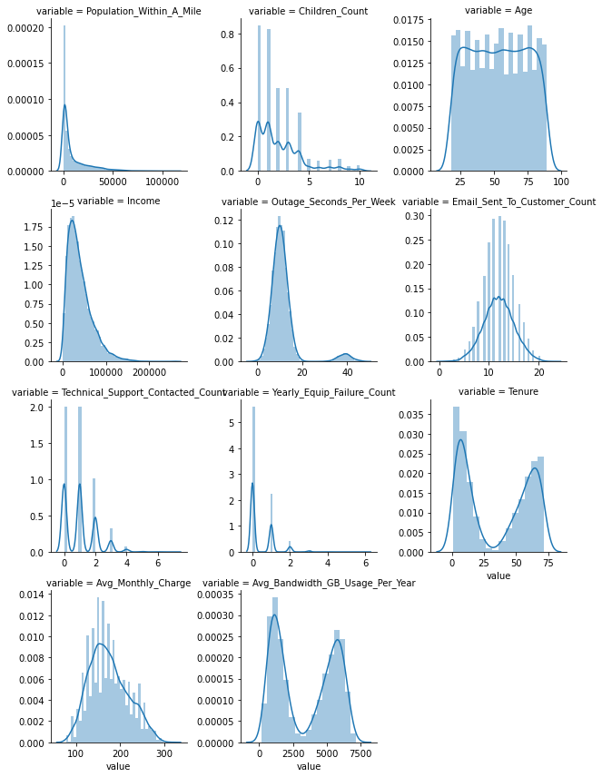

```python
# Continuous Variables
nd = pd.melt(df, value_vars = continuous_variables)
n1 = sns.FacetGrid (nd, col='variable', col_wrap=3, sharex=False, sharey = False)
n1 = n1.map(sns.distplot, 'value')
n1
```

```python
predictor_variables = predictor_variables.drop(columns=['Population_Within_A_Mile', 'Children_Count', 'Income', 'Outage_Seconds_Per_Week', 'Technical_Support_Contacted_Count', 'Yearly_Equip_Failure_Count'], axis=1)
```

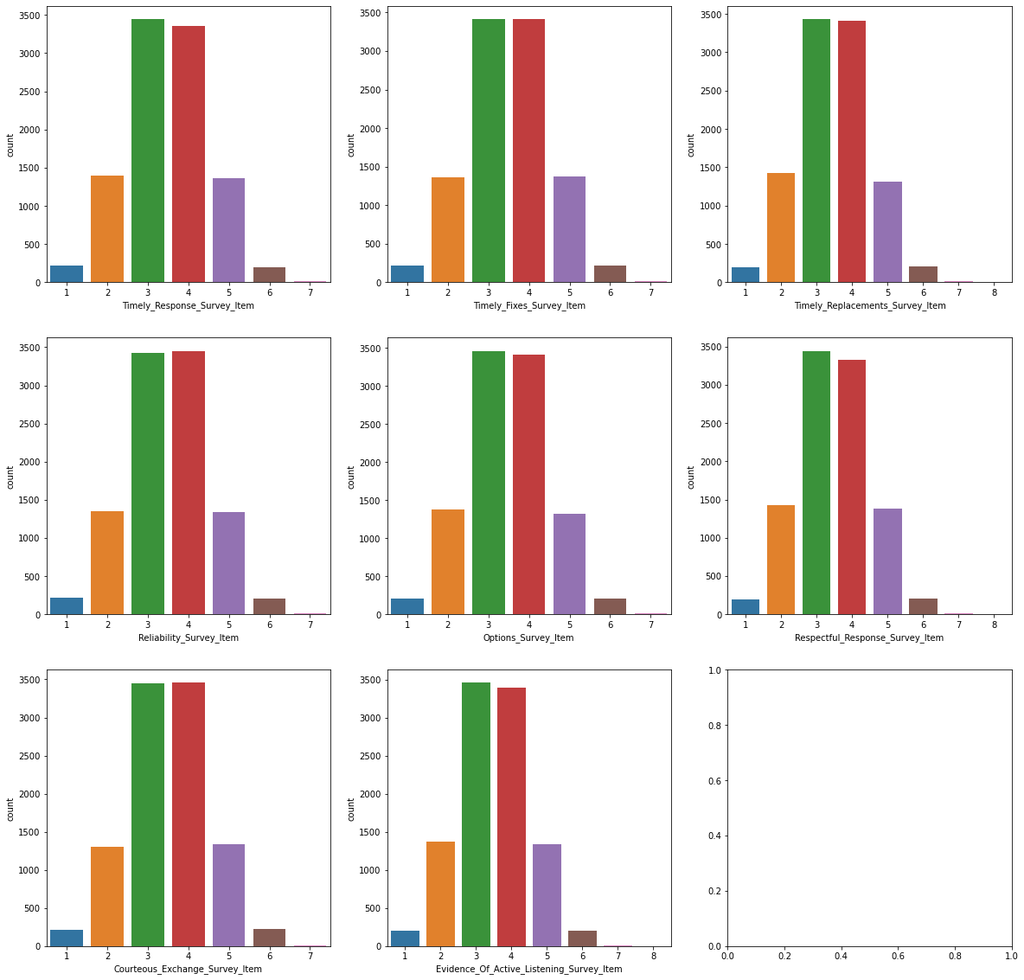

```python
# Discrete Ordinal Variables
fig, ax =plt.subplots(3,3,figsize=(20,20))

sns.countplot(df["Timely_Response_Survey_Item"], ax=ax[0][0])
sns.countplot(df["Timely_Fixes_Survey_Item"], ax=ax[0][1])
sns.countplot(df["Timely_Replacements_Survey_Item"], ax=ax[0][2])

sns.countplot(df["Reliability_Survey_Item"], ax=ax[1][0])
sns.countplot(df["Options_Survey_Item"], ax=ax[1][1])
sns.countplot(df["Respectful_Response_Survey_Item"], ax=ax[1][2])

sns.countplot(df["Courteous_Exchange_Survey_Item"], ax=ax[2][0])
sns.countplot(df["Evidence_Of_Active_Listening_Survey_Item"], ax=ax[2][1])

fig.show()
```

## Bivariate Visualization and Analysis

There are two types of possible combinations of variable types when looking at churn (categorical-categorical and categorical-continuous). Below is listed the recommended ways to conduct a bivariate analysis on these combinations.

### Continuous-Continuous Variables:

Not included because Churn is a Categorical variable and the assignment requests the target variable (churn) to be used in the bivariate visualizations.

### Categorical-Categorical Variables:

1. cross tables
2. stacked column charts
3. chi-square test

### Categorical-Continuous Variables:¶

1. z-test/t-test
2. ANOVA test
3. scatterplot

### Categorical-Categorical Variables

[figure not shown]

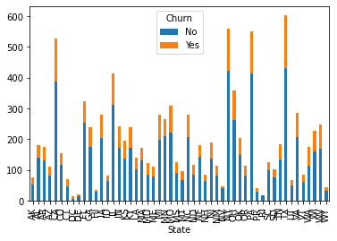

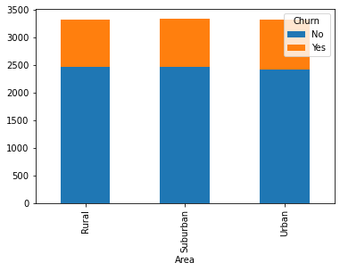

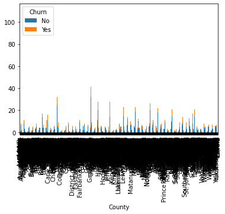

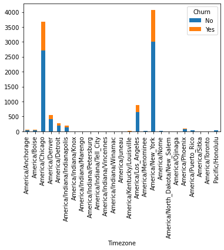

[figure not shown]

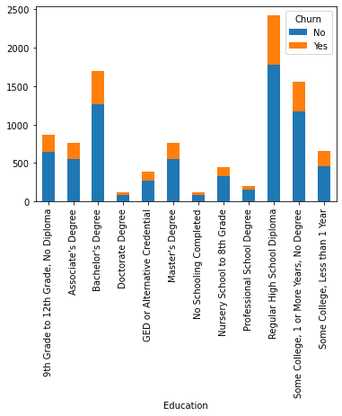

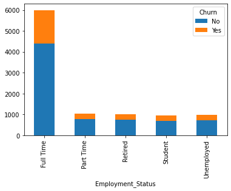

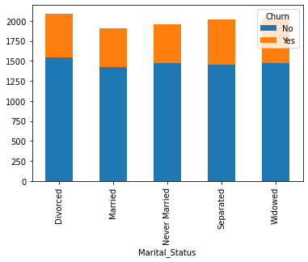

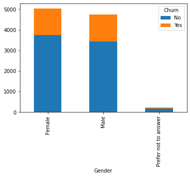

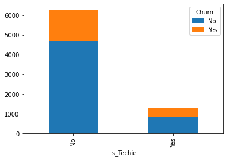

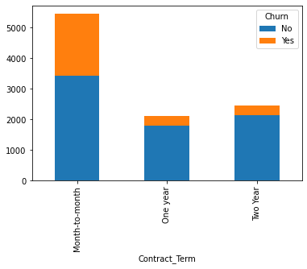

[13 more figures not shown]

```python
for var in categorical_variables:
    area_crosstab = pd.crosstab(categorical_variables[var], df["Churn"])
    area_crosstab.plot(kind='bar', stacked = True)
    crosstab_norm = area_crosstab.div(area_crosstab.sum(1), axis=0)
```